# Statistics & Data Science Jobs

**Dr. Matthew Beckman**  
Asst Professor & Director of Undergraduate Programs  
Department of Statistics  
Penn State University

beckman@psu.edu

### Here’s a link & QR code for this webpage:

### https://mdbeckman.github.io/PSU-Data-Science/

[figure not shown]

## Are there really jobs in Data Science & Statistics?

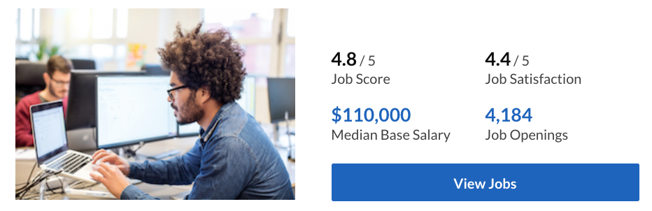

image access: www.glassdoor.com/List/Best-Jobs-in-America-LST_KQ0,20.htm

- Yes! but you should [Google it yourself](http://lmgtfy.com/?q=data+scientist+careers)
- Frequently listed among top careers in 2017 by
  - [Glassdoor (Data Scientist #1)](https://www.glassdoor.com/List/Best-Jobs-in-America-LST_KQ0,20.htm)
  - [US News & World Report (Statistician #4)](https://money.usnews.com/careers/best-jobs/rankings/the-100-best-jobs)
  - [CNN Money (Acturay #20; Biostatistian #48)](http://money.cnn.com/pf/best-jobs/2017/list/index.html)
  - [CBS News](https://www.cbsnews.com/media/the-best-11-jobs-in-america-for-2017/12/)
  - [CNBC](https://www.cnbc.com/2017/01/23/the-50-best-jobs-in-america-in-2017.html)
  - and lots more…
- It even pays well (but that’s not why you should do it–or any other job)

## Why is it so popular?

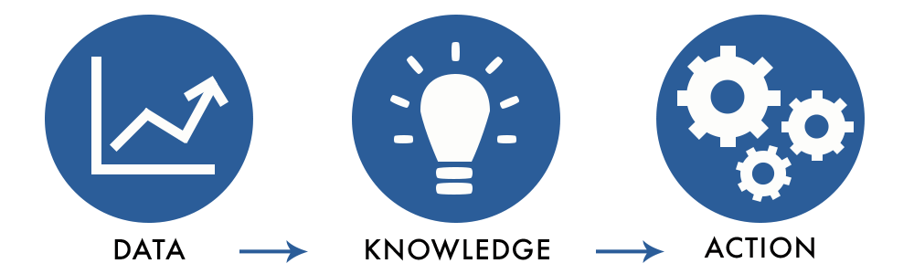

image access: https://goo.gl/images/w2YmVH

#### …because Data

- There’s a **ton** of it and [more data will be generated in the next 2 years than the previous 5000 years of humanity](https://appdevelopermagazine.com/4773/2016/12/23/more-data-will-be-created-in-2017-than-the-previous-5,000-years-of-humanity-/)
  - Anyone wondering what kind of data they produced in 2983 BC?
  - Here’s some [3000 BC stuff](https://en.wikipedia.org/wiki/30th_century_BC) just to get our minds around that statement…
    - [City of Troy Founded](https://en.wikipedia.org/wiki/Troy)
    - [They started building Stonehenge](https://en.wikipedia.org/wiki/Stonehenge)
    - [Earliest written language on Earth (Sumerian)](https://en.wikipedia.org/wiki/Sumerian_language)
- **Everyone** has it, produces it, uses it, and people want to learn from it
  - Google, Amazon, Facebook, Netflix, Target, and the NSA are *really* good at learning from it… that’s how
    - Gmail filters your spam
    - Amazon recommends stuff for you to buy (that you didn’t know you want)
    - Facebook autotags your photos
    - Netflix picks the right shows & movies
    - Target prints just the right coupons at checkout… ([How Target Figured Out A Teen Girl Was Pregnant Before Her Father Did](https://www.forbes.com/sites/kashmirhill/2012/02/16/how-target-figured-out-a-teen-girl-was-pregnant-before-her-father-did/#6afc1c6d6668))
- There are **so many** cool questions to answer
  - We finally have the data, skills, and tools
  - We just *don’t* have enough people to work on them… ([a 2011 estimate endorsed by the US Govt (NIST) thinks we’re short by about 190,000 with “deep analytical skills”](https://bigdatawg.nist.gov/pdf/MGI_big_data_full_report.pdf))

## What skills do you need?

[figure not shown]

## How can you get started?

- Start learning statistics and computer science
  - Classes at school
  - MOOCs–massive open online courses
  - Web tutorials like DataCamp.com
- Penn State
  - Nittany Data Labs
  - PSU Stat Club
  - We R… (Penn State R User Group)
  - Statistics Major (or Minor) with tracks available for
    - Actuarial Science
    - Applied Statistics
    - Biostatistics
    - Computational Statistics
    - Graduate Studies
  - Data Science Major with tracks for
    - Applied DS
    - Computational DS
    - Statistical Modeling DS

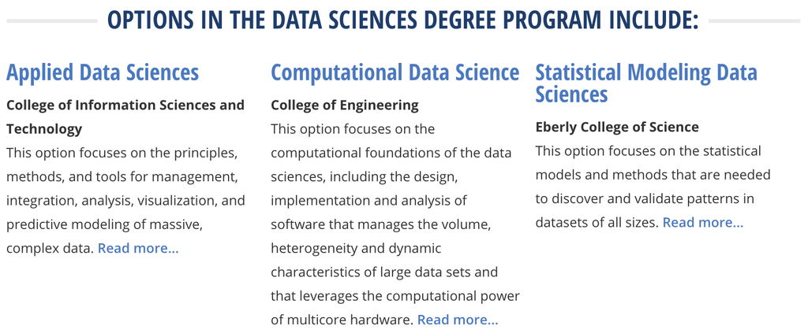

image access: https://ist.psu.edu/students/undergrad/majors/ds

## Contact Info

Dr. Matthew Beckman  
Asst. Research Professor & Director of Undergraduate Programs  
Department of Statistics  
Penn State University

beckman@psu.edu